# Прогнозирование оттока клиентов

### Описание проекта

Заказчик - фитнес -клуб поставил задачу на основе данных клиентов спрогнозировать отток клиентов, сформулировать основные выводы и разработать рекомендации по повышению качества работы с клиентами.

### Загрузка данных

```python
import pandas as pd # импорт библиотек
import numpy as np
import matplotlib.pyplot as plt
import scipy.stats as stats
import seaborn as sns
from sklearn.model_selection import train_test_split
from sklearn.preprocessing import StandardScaler
from sklearn.linear_model import LogisticRegression
from sklearn.ensemble import RandomForestClassifier, GradientBoostingClassifier
from sklearn.metrics import accuracy_score, precision_score, recall_score, f1_score
from scipy.cluster.hierarchy import dendrogram, linkage
from sklearn.cluster import KMeans
```

```python
df = pd.read_csv('/datasets/gym_churn.csv') # чтение файла
```

```python
df.head()
```

|  | gender | Near_Location | Partner | Promo_friends | Phone | Contract_period | Group_visits | Age | Avg_additional_charges_total | Month_to_end_contract | Lifetime | Avg_class_frequency_total | Avg_class_frequency_current_month | Churn |
| --- | --- | --- | --- | --- | --- | --- | --- | --- | --- | --- | --- | --- | --- | --- |
| 0 | 1 | 1 | 1 | 1 | 0 | 6 | 1 | 29 | 14.227470 | 5.0 | 3 | 0.020398 | 0.000000 | 0 |
| 1 | 0 | 1 | 0 | 0 | 1 | 12 | 1 | 31 | 113.202938 | 12.0 | 7 | 1.922936 | 1.910244 | 0 |
| 2 | 0 | 1 | 1 | 0 | 1 | 1 | 0 | 28 | 129.448479 | 1.0 | 2 | 1.859098 | 1.736502 | 0 |
| 3 | 0 | 1 | 1 | 1 | 1 | 12 | 1 | 33 | 62.669863 | 12.0 | 2 | 3.205633 | 3.357215 | 0 |
| 4 | 1 | 1 | 1 | 1 | 1 | 1 | 0 | 26 | 198.362265 | 1.0 | 3 | 1.113884 | 1.120078 | 0 |

```python
df.info() # информация о данных
```

```
<class 'pandas.core.frame.DataFrame'>
RangeIndex: 4000 entries, 0 to 3999
Data columns (total 14 columns):
 #   Column                             Non-Null Count  Dtype
---  ------                             --------------  -----
 0   gender                             4000 non-null   int64
 1   Near_Location                      4000 non-null   int64
 2   Partner                            4000 non-null   int64
 3   Promo_friends                      4000 non-null   int64
 4   Phone                              4000 non-null   int64
 5   Contract_period                    4000 non-null   int64
 6   Group_visits                       4000 non-null   int64
 7   Age                                4000 non-null   int64
 8   Avg_additional_charges_total       4000 non-null   float64
 9   Month_to_end_contract              4000 non-null   float64
 10  Lifetime                           4000 non-null   int64
 11  Avg_class_frequency_total          4000 non-null   float64
 12  Avg_class_frequency_current_month  4000 non-null   float64
 13  Churn                              4000 non-null   int64
dtypes: float64(4), int64(10)
memory usage: 437.6 KB
```

Данные пользователя за предыдущий до проверки факта оттока месяц:

'gender' — пол

'Near_Location' — проживание или работа в районе, где находится фитнес-центр

'Partner' — сотрудник компании-партнёра клуба (сотрудничество с компаниями, чьи сотрудники могут получать скидки на абонемент — в таком случае фитнес-центр хранит информацию о работодателе клиента)

Promo_friends — факт первоначальной записи в рамках акции «приведи друга» (использовал промо-код от знакомого при оплате первого абонемента)

'Phone' — наличие контактного телефона

'Age' — возраст

'Lifetime' — время с момента первого обращения в фитнес-центр (в месяцах)

Информация на основе журнала посещений, покупок и информация о текущем статусе абонемента клиента

'Contract_period' — длительность текущего действующего абонемента (месяц, 3 месяца, 6 месяцев, год)

'Month_to_end_contract' — срок до окончания текущего действующего абонемента (в месяцах)

'Group_visits' — факт посещения групповых занятий

'Avg_class_frequency_total' — средняя частота посещений в неделю за все время с начала действия абонемента

'Avg_class_frequency_current_month' — средняя частота посещений в неделю за предыдущий месяц

'Avg_additional_charges_total' — суммарная выручка от других услуг фитнес-центра: кафе, спорт-товары, косметический и массажный салон

'Churn' — факт оттока в текущем месяце;

Вывод: в датафрейме приведены данные клиентов фитнес-центра. Приведены 13 признаков и одна целевая переменная- достаточно большое количество признаков. Необходимо обратить внимание действительно ли все они оказывают влияние на целевую переменную. Пропуски отсутствуют, типы данных столбцов менять не требуется.

### Исследовательский анализ данных (EDA)

#### Посмотрите на датасет: есть ли в нем отсутствующие признаки, изучите средние значения и стандартные отклонения

```python
df.isna().sum() # подсчет количества пропусков
```

```
gender                               0
Near_Location                        0
Partner                              0
Promo_friends                        0
Phone                                0
Contract_period                      0
Group_visits                         0
Age                                  0
Avg_additional_charges_total         0
Month_to_end_contract                0
Lifetime                             0
Avg_class_frequency_total            0
Avg_class_frequency_current_month    0
Churn                                0
dtype: int64
```

```python
df.describe() # вывод средних значений и стандартных отклонений
```

|  | gender | Near_Location | Partner | Promo_friends | Phone | Contract_period | Group_visits | Age | Avg_additional_charges_total | Month_to_end_contract | Lifetime | Avg_class_frequency_total | Avg_class_frequency_current_month | Churn |
| --- | --- | --- | --- | --- | --- | --- | --- | --- | --- | --- | --- | --- | --- | --- |
| count | 4000.000000 | 4000.000000 | 4000.000000 | 4000.000000 | 4000.000000 | 4000.000000 | 4000.000000 | 4000.000000 | 4000.000000 | 4000.000000 | 4000.000000 | 4000.000000 | 4000.000000 | 4000.000000 |
| mean | 0.510250 | 0.845250 | 0.486750 | 0.308500 | 0.903500 | 4.681250 | 0.412250 | 29.184250 | 146.943728 | 4.322750 | 3.724750 | 1.879020 | 1.767052 | 0.265250 |
| std | 0.499957 | 0.361711 | 0.499887 | 0.461932 | 0.295313 | 4.549706 | 0.492301 | 3.258367 | 96.355602 | 4.191297 | 3.749267 | 0.972245 | 1.052906 | 0.441521 |
| min | 0.000000 | 0.000000 | 0.000000 | 0.000000 | 0.000000 | 1.000000 | 0.000000 | 18.000000 | 0.148205 | 1.000000 | 0.000000 | 0.000000 | 0.000000 | 0.000000 |
| 25% | 0.000000 | 1.000000 | 0.000000 | 0.000000 | 1.000000 | 1.000000 | 0.000000 | 27.000000 | 68.868830 | 1.000000 | 1.000000 | 1.180875 | 0.963003 | 0.000000 |
| 50% | 1.000000 | 1.000000 | 0.000000 | 0.000000 | 1.000000 | 1.000000 | 0.000000 | 29.000000 | 136.220159 | 1.000000 | 3.000000 | 1.832768 | 1.719574 | 0.000000 |
| 75% | 1.000000 | 1.000000 | 1.000000 | 1.000000 | 1.000000 | 6.000000 | 1.000000 | 31.000000 | 210.949625 | 6.000000 | 5.000000 | 2.536078 | 2.510336 | 1.000000 |
| max | 1.000000 | 1.000000 | 1.000000 | 1.000000 | 1.000000 | 12.000000 | 1.000000 | 41.000000 | 552.590740 | 12.000000 | 31.000000 | 6.023668 | 6.146783 | 1.000000 |

#### Посмотрите на средние значения признаков в двух группах — тех, кто ушел в отток и тех, кто остался

```python
df.groupby('Churn').mean() # средние значения признаков в двух группах — тех, кто ушел в отток и тех, кто остался
```

| Churn | gender | Near_Location | Partner | Promo_friends | Phone | Contract_period | Group_visits | Age | Avg_additional_charges_total | Month_to_end_contract | Lifetime | Avg_class_frequency_total | Avg_class_frequency_current_month |
| --- | --- | --- | --- | --- | --- | --- | --- | --- | --- | --- | --- | --- | --- |
| 0 | 0.510037 | 0.873086 | 0.534195 | 0.353522 | 0.903709 | 5.747193 | 0.464103 | 29.976523 | 158.445715 | 5.283089 | 4.711807 | 2.024876 | 2.027882 |
| 1 | 0.510839 | 0.768143 | 0.355325 | 0.183789 | 0.902922 | 1.728558 | 0.268615 | 26.989632 | 115.082899 | 1.662582 | 0.990575 | 1.474995 | 1.044546 |

Практически все средние значения признаков клиентов, ушедших в отток, меньше, чем средние значения признаков активных клиентов. Большое различие можно отследить в признаках Contract_period (длительность текущего абонемента), Avg_additional_charges_total (суммарная выручка от других услуг), Month_to_end_contract (кол-во месяцев до окончания абонемента), Lifetime (время с момента первого обращения в фитнес-центр).

#### Постройте столбчатые гистограммы и распределения признаков для тех, кто ушёл (отток) и тех, кто остался (не попали в отток);

```python
df1=df.query('Churn==0')
df2=df.query('Churn==1')
```

```python
columns = df.columns # список названий столбцов
```

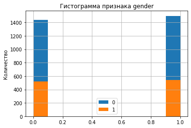

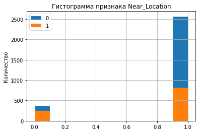

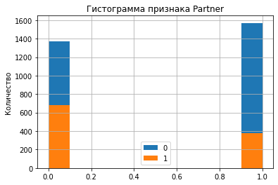

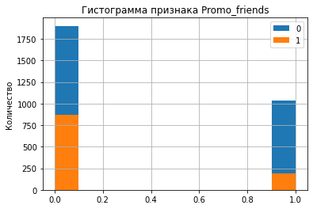

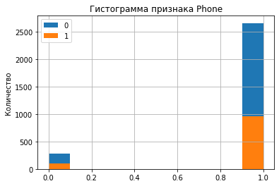

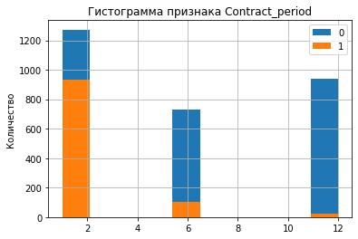

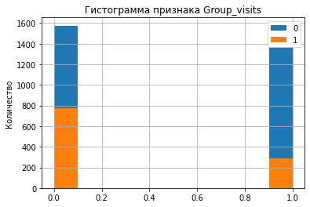

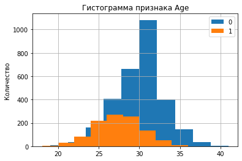

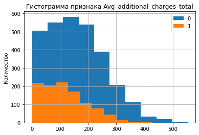

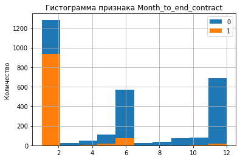

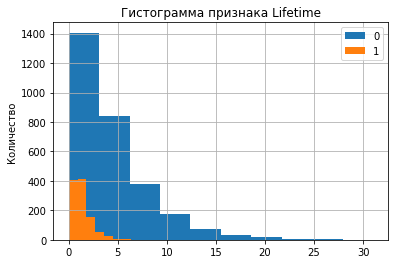

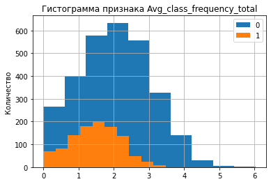

[2 more figures not shown]

```python
for column in columns:
    # построение столбчатых гистограмм признаков для групп оттока и активных клиентов

    ax = df.query('Churn==0')[column].hist(label=0, bins=10)
    ax = df.query('Churn==1')[column].hist(label=1, bins=10)
    plt.title(f'Гистограмма признака {column}')
    plt.legend()
    plt.ylabel('Количество')
    plt.show()
```

[figure not shown]

[figure not shown]

[figure not shown]

[figure not shown]

[figure not shown]

[figure not shown]

[figure not shown]

[figure not shown]

[figure not shown]

[figure not shown]

[figure not shown]

[figure not shown]

[4 more figures not shown]

```python
fig, axes = plt.subplots(nrows=3, ncols=4, figsize=(16, 10))
for column in columns: # построение столбчатых гистограмм признаков для групп оттока и активных клиентов
    ax = plt.subplots(3, 4)
    ax = df.query('Churn==0')[column].hist(label=0, bins=10)
    ax = df.query('Churn==1')[column].hist(label=1, bins=10)
    plt.title(f'Гистограмма признака {column}')
    plt.ylabel('Количество')
    plt.legend()
    plt.show()
```

[output not shown]

[figure not shown]

```python
plt.figure(figsize=(15, 10))
for i, col in enumerate(df.columns):

    plt.subplot(3, 4, i+1)
    ax = df.query('Churn==0')[col].hist(label=0, bins=10)
    ax = df.query('Churn==1')[col].hist(label=1, bins=10)
    plt.title(f'Гистограмма признака {column}')
    plt.ylabel('Количество')
    plt.legend()
```

```python
#plt.figure(figsize=(40,30))
#sns.boxplot(x="variable", y="value", data=pd.melt(df2))
#plt.ylim(0,50)
#plt.show()
```

#### Постройте матрицу корреляций и отобразите её.

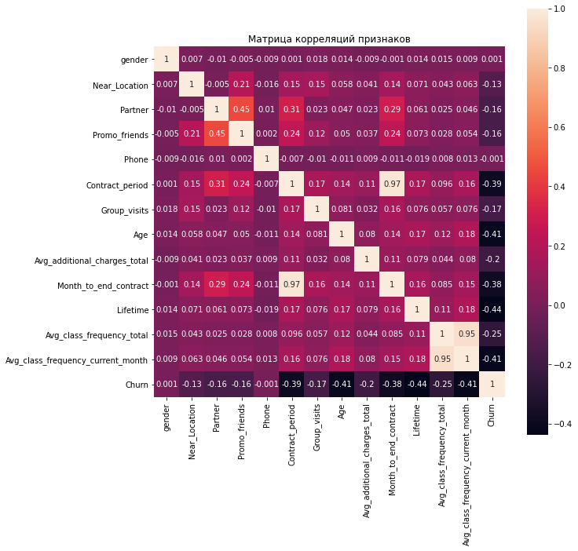

```python
# построим и отрисуем матрицу корреляций признаков
cm = df.corr() # вычисляем матрицу корреляций

fig, ax = plt.subplots(figsize =(10, 10))
# нарисуем тепловую карту с подписями для матрицы корреляций
sns.heatmap(cm.round(3), annot=True, square=True)
plt.title('Матрица корреляций признаков')
plt.show()
```

1.Сильно коррелируются между собой признаки "количество месяцев до конца контракта" и "период контракта". В следующем шаге удалим один из этих признаков, обучим модель, посчитаем метрики и сравним, как это сказалось на качестве обучения модели.

2.На целевую переменную больше всего оказывают влияние признаки: Lifetime(время с момента первого обращения в фитнес-центр), Age(возраст), Avg_class_frequency_current_month(средняя частота посещений в неделю за предыдущий месяц), 'Contract_period'(длительность текущего действующего абонемента), Month_to_end_contract(срок до окончания текущего действующего абонемента (в месяцах).

### Постройте модель прогнозирования оттока пользователей

#### Постройте модель бинарной классификации пользователей, где целевой признак — факт оттока пользователя в следующем месяце

##### Разбейте данные на обучающую и валидационную выборку функцией train_test_split()

```python
X = df.drop('Churn', axis = 1) # матрица признаков
y = df['Churn'] # целевая переменная (факт оттока)
```

```python
# разделяем модель на обучающую и валидационную выборку
X_train, X_test, y_train, y_test = train_test_split(X, y, test_size=0.2, random_state=0)
```

#### Обучите модель на train-выборке двумя способами: логистической регрессией и случайным лесом и расчитайте метрики

```python
model = LogisticRegression(solver='liblinear') # зададим алгоритм для нашей модели логистическая регрессия
```

```python
# обучите модель

model.fit(X_train, y_train)
# воспользуйтесь уже обученной моделью, чтобы сделать прогнозы
predictions = model.predict(X_test)
probabilities = model.predict_proba(X_test)[:,1]

# выведите значения predictions и probabilities на экран
display(predictions[:10])
display(probabilities[:10])
```

```
array([0, 1, 0, 1, 0, 0, 0, 0, 0, 0])
```

```
array([0.00383172, 0.95137122, 0.41051988, 0.92913348, 0.03123081,
       0.00479106, 0.03791697, 0.00405993, 0.19068563, 0.00693673])
```

Посчитаем метрики для данной модели accuracy_score, precision_score, recall_score

```python
display('Accuracy: {:.2f}'.format(accuracy_score(y_test, predictions))) # доля правильных ответов
display('Precision: {:.2f}'.format(precision_score(y_test, predictions))) # точность
display('Recall: {:.2f}'.format(recall_score(y_test, predictions))) # полнота
```

```
'Accuracy: 0.93'
```

```
'Precision: 0.86'
```

```
'Recall: 0.83'
```

Обучим модель по алгоритму случайный лес и посчитаем метрики

```python
rf_model = RandomForestClassifier(n_estimators=100, random_state=0) # зададим алгоритм для нашей модели случайный лес
# обучим модель случайного леса
rf_model.fit(X_train, y_train)
# воспользуемся уже обученной моделью, чтобы сделать прогнозы
rf_predictions = rf_model.predict(X_test)
rf_probabilities = rf_model.predict_proba(X_test)[:,1]
```

```python
display('Accuracy: {:.2f}'.format(accuracy_score(y_test, rf_predictions))) # доля правильных ответов
display('Precision: {:.2f}'.format(precision_score(y_test, rf_predictions))) # точность
display('Recall: {:.2f}'.format(recall_score(y_test, rf_predictions))) # полнота
```

```
'Accuracy: 0.92'
```

```
'Precision: 0.84'
```

```
'Recall: 0.82'
```

Вывод: метрики, полученные после обучения модели по алгоритму "логистическая регрессия", выше, следовательно, модель по данному алгоритму обучилась более качественно.

#### Обучим модель с удаленным признаком Month_to_end_contract(количество месяцев до окончания абонемента)

```python
X1 = df.drop('Churn', axis = 1)
X1 = df.drop('Month_to_end_contract', axis = 1)# матрица признаков с удаленным признаком
y = df['Churn'] # целевая переменная (факт оттока)
```

```python
# разделяем модель на обучающую и валидационную выборку
X_train1, X_test1, y_train1, y_test1 = train_test_split(X1, y, test_size=0.2, random_state=0)
```

```python
# обучите модель

model.fit(X_train1, y_train1)
# воспользуйтесь уже обученной моделью, чтобы сделать прогнозы
predictions1 = model.predict(X_test1)
probabilities1 = model.predict_proba(X_test1)[:,1]

# выведите значения predictions и probabilities на экран
display(predictions1[:10])
display(probabilities1[:10])
```

```
array([0, 1, 0, 1, 0, 0, 0, 0, 1, 0])
```

```
array([7.73354636e-04, 9.96446054e-01, 1.35284058e-02, 9.94665146e-01,
       2.16234612e-03, 1.18694959e-03, 3.02602221e-03, 7.03831125e-04,
       9.78973980e-01, 1.62134107e-03])
```

```python
display('Accuracy: {:.2f}'.format(accuracy_score(y_test1, predictions1))) # доля правильных ответов
display('Precision: {:.2f}'.format(precision_score(y_test1, predictions1))) # точность
display('Recall: {:.2f}'.format(recall_score(y_test1, predictions1))) # полнота
```

```
'Accuracy: 1.00'
```

```
'Precision: 1.00'
```

```
'Recall: 1.00'
```

```python
rf_model = RandomForestClassifier(n_estimators=100, random_state=0) # зададим алгоритм для нашей модели случайный лес
# обучим модель случайного леса
rf_model.fit(X_train1, y_train1)
# воспользуемся уже обученной моделью, чтобы сделать прогнозы
rf_predictions1 = rf_model.predict(X_test1)
rf_probabilities1 = rf_model.predict_proba(X_test1)[:,1]
```

```python
display('Accuracy: {:.2f}'.format(accuracy_score(y_test1, rf_predictions))) # доля правильных ответов
display('Precision: {:.2f}'.format(precision_score(y_test1, rf_predictions))) # точность
display('Recall: {:.2f}'.format(recall_score(y_test1, rf_predictions))) # полнота
```

```
'Accuracy: 0.92'
```

```
'Precision: 0.84'
```

```
'Recall: 0.82'
```

Далее в исследовании использьзую все признаки из данных.

### Сделайте кластеризацию пользователей

Стандартизируем признаки

```python
scaler = StandardScaler() # создаём объект класса scaler (нормализатор)
x_sc = scaler.fit_transform(df.drop(columns = ['Churn'])) # обучаем нормализатор и преобразуем набор данных
```

```python
linked = linkage(x_sc, method = 'ward')
```

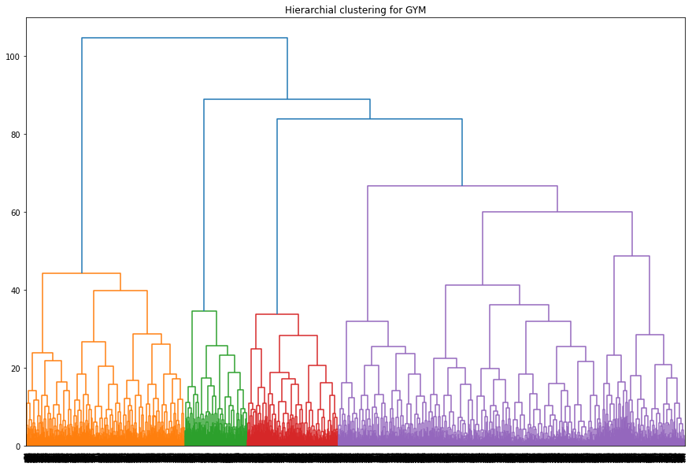

```python
plt.figure(figsize=(15, 10))  # отрисовка дендрограммы признаков
dendrogram(linked, orientation='top')
plt.title('Hierarchial clustering for GYM')
plt.show()
```

На основании данной дендограммы можно выделить 4 кластера.

#### Обучите модель кластеризации на основании алгоритма K-Means и спрогнозируйте кластеры клиентов.

```python
# задаём модель k_means с числом кластеров 5 и фиксируем значение random_state
km = KMeans(n_clusters=5, random_state=0)
# прогнозируем кластеры для наблюдений (алгоритм присваивает им номера от 0 до 2)
labels = km.fit_predict(df)

# сохраняем метки кластера в поле нашего датасета
df['cluster_km'] = labels

# выводим статистику по средним значениям наших признаков по кластеру
display(df.groupby(['cluster_km']).mean())
```

| cluster_km | gender | Near_Location | Partner | Promo_friends | Phone | Contract_period | Group_visits | Age | Avg_additional_charges_total | Month_to_end_contract | Lifetime | Avg_class_frequency_total | Avg_class_frequency_current_month | Churn |
| --- | --- | --- | --- | --- | --- | --- | --- | --- | --- | --- | --- | --- | --- | --- |
| 0 | 0.514091 | 0.839650 | 0.451895 | 0.279883 | 0.897959 | 4.301263 | 0.407191 | 28.973761 | 105.932804 | 3.996113 | 3.544218 | 1.852564 | 1.708264 | 0.334305 |
| 1 | 0.511435 | 0.844075 | 0.495842 | 0.320166 | 0.902287 | 4.755717 | 0.423077 | 29.401247 | 174.873445 | 4.376299 | 3.749480 | 1.895200 | 1.785569 | 0.226611 |
| 2 | 0.468635 | 0.856089 | 0.516605 | 0.332103 | 0.926199 | 5.822878 | 0.431734 | 29.845018 | 356.481960 | 5.383764 | 4.420664 | 2.019260 | 2.009382 | 0.044280 |
| 3 | 0.508721 | 0.824612 | 0.488372 | 0.293605 | 0.907946 | 4.198643 | 0.387597 | 28.908915 | 35.600722 | 3.855620 | 3.394380 | 1.836755 | 1.692641 | 0.349806 |
| 4 | 0.521246 | 0.881020 | 0.511331 | 0.347025 | 0.898017 | 5.400850 | 0.433428 | 29.344193 | 250.984767 | 5.001416 | 4.169972 | 1.903480 | 1.843255 | 0.178470 |

Вывод:

1. В том кластере, где больше всего выручки от других услуг, там меньше всего вероятность оттока (2 и 4 кластеры).
2. Больше всего вероятность к отттоку в 0 и 3 кластерах. Для этих кластеров характерно наиболее короткий период абонемента, более молодой возраст клиентов, меньше период до окончания контракта, меньше всего времени с первого обращения в фитнес-центр.